# BRFSS 2017 Survey EDA-BMI

Amanda Kimball

11/22/2020

The Smart: City and county survey data put together by the Center for Disease Control and Prevention: Behavioral risk factor surveillance system (Smart data, 2017). Contains a number of survey response data that is equally distributed across a range of areas referred to as Metropolitan and Micropolitan statistical areas. The survey data covers health indicators, diet choices, health insurance availability, demographics, and economic factors. I initially uploaded the data and pulled out the data related to body mass index and age demographics.

```r
library(foreign)
BRFSS2017 <- read.xport("MMSA2017.XPT")
```

I needed to create an additional factor with the county MMSA name and state separated from the full MMSANAME field. I used the gsub function to remove the MSA test and created the 2 new columns.

```r
data <- subset(BRFSS2017, select = c(47:49, 122:129, 174, 175, 177))
data$County <- lapply(data$MMSANAME, as.character)

data$County <- gsub(", Metropolitan Statistical Area", "", data$County)
data$County <- gsub(", Micropolitan Statistical Area", "", data$County)
data$County <- gsub(", Metropolitan Division", "", data$County)
data$State <- gsub(".*,", "", data$County)
data$State <- gsub(" ", "", data$State)
data$County <- gsub(",.*", "", data$County)
str(data)
```

```
## 'data.frame':    230875 obs. of  16 variables:
##  $ WEIGHT2  : num  200 140 300 175 160 250 170 155 160 119 ...
##  $ HEIGHT3  : num  507 505 605 504 504 511 502 504 504 506 ...
##  $ PREGNANT : num  NA NA NA 2 NA NA NA NA NA NA ...
##  $ X_AGEG5YR: num  9 10 1 2 13 3 10 13 13 13 ...
##  $ X_AGE65YR: num  1 2 1 1 2 1 2 2 2 2 ...
##  $ X_AGE80  : num  61 65 21 28 80 31 67 80 80 80 ...
##  $ X_AGE_G  : num  5 6 1 2 6 2 6 6 6 6 ...
##  $ WTKG3    : num  9072 6350 13608 7938 7257 ...
##  $ X_BMI5   : num  3132 2330 3557 3004 2746 ...
##  $ X_BMI5CAT: num  4 2 4 4 3 4 4 3 3 2 ...
##  $ X_RFBMI5 : num  2 1 2 2 2 2 2 2 2 1 ...
##  $ X_MMSA   : num  10100 10100 10100 10100 10100 10100 10100 10100 10100 10100 ...
##  $ X_MMSAWT : num  110.2 28.6 115.6 376 20.7 ...
##  $ MMSANAME : Factor w/ 136 levels "Aberdeen, SD, Micropolitan Statistical Area",..: 1 1 1 1 1 1 1 1 1 1 ...
##  $ County   : chr  "Aberdeen" "Aberdeen" "Aberdeen" "Aberdeen" ...
##  $ State    : chr  "SD" "SD" "SD" "SD" ...
```

Here are the calculated body mass indicator variables. As shown there are several missing values.

```r
summary(data[9:11])
```

```
##      X_BMI5        X_BMI5CAT        X_RFBMI5
##  Min.   :1205    Min.   :1.00    Min.   :1.000
##  1st Qu.:2373    1st Qu.:2.00    1st Qu.:1.000
##  Median :2695    Median :3.00    Median :2.000
##  Mean   :2797    Mean   :2.94    Mean   :2.281
##  3rd Qu.:3096    3rd Qu.:4.00    3rd Qu.:2.000
##  Max.   :9931    Max.   :4.00    Max.   :9.000
##  NA's   :19570   NA's   :19570
```

There are a significant number of NA’s for the BMI index. I am going to focus on one county’s data to understand the nuances in the data set and then apply what I have learned to the other counties. Aberdeen has 25 NA values of 261 entries for the BMI indexes (~9% of the entries which is consistent with the population). There are 2 values listed as pregnant (rows 311 & 453). I can safely remove the individuals listed as pregnant as outliers with a cause. It appears that the remaining values are missing the weight or height factor either listed as 9999 (Refused) or 7777 (Not sure).

```r
Aberdeen <- data[data$X_MMSA == 10100,]
```

I calculated the average for the Aberdeen and compared it with the average for the entire data sample and find that they are 27.9 and 27.5 kg/m2. The weight factor ‘X_MMSAWT’ is used to adjust for sampling methodology. Note that the documentation indicates a 2 decimal place value. Based off this analysis, I am going to impute the average for the population as the NAs.

```r
Aberdeenavg <- mean((Aberdeen$X_BMI5*Aberdeen$X_MMSAWT),na.rm=TRUE)/mean(Aberdeen$X_MMSAWT,na.rm=TRUE)
popavg <- mean((data$X_BMI5*data$X_MMSAWT), na.rm=TRUE)/mean(data$X_MMSAWT,na.rm=TRUE)
```

```r
data <- data[!(data$PREGNANT == 1),]
index <- is.na(data$X_BMI5)
data$X_BMI5[index] <- popavg
data$X_BMI5CAT[index] <- 3
data$X_RFBMI5[index] <- 2
summary(data[9:11])
```

```
##      X_BMI5       X_BMI5CAT       X_RFBMI5
##  Min.   :1221   Min.   :1.00   Min.   :1.000
##  1st Qu.:2750   1st Qu.:3.00   1st Qu.:2.000
##  Median :2750   Median :3.00   Median :2.000
##  Mean   :2751   Mean   :2.97   Mean   :1.926
##  3rd Qu.:2750   3rd Qu.:3.00   3rd Qu.:2.000
##  Max.   :9931   Max.   :4.00   Max.   :2.000
```

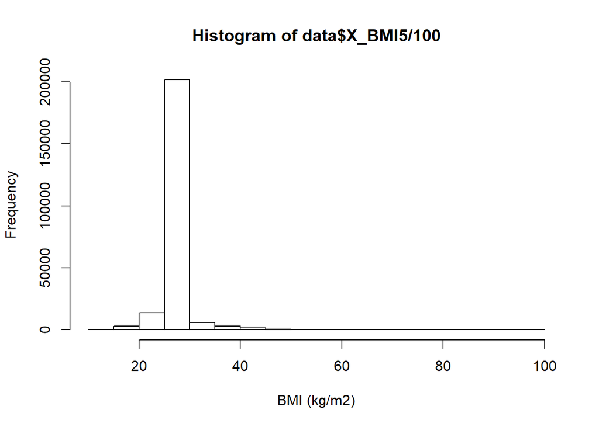

```r
hist(data$X_BMI5/100, xlab = "BMI (kg/m2)", breaks = 20)
```

The distribution of BMI does not correlate with age.

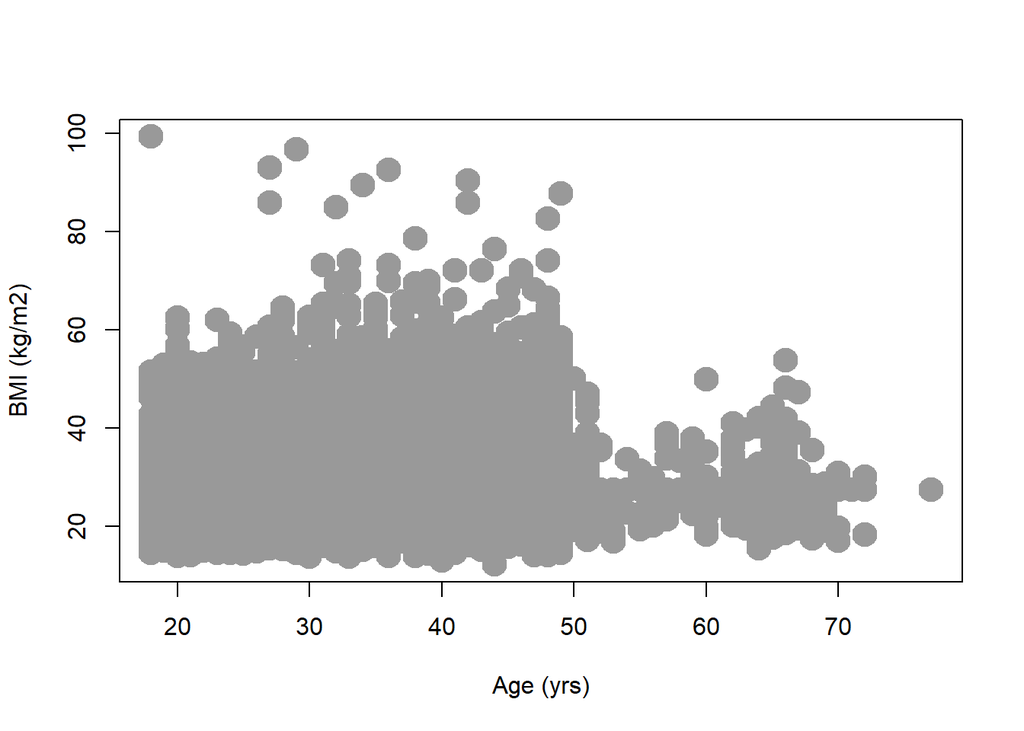

```r
plot(data$X_AGE80, data$X_BMI5/100, ylab = "BMI (kg/m2)", xlab = "Age (yrs)", lwd = 10, col = "grey60")
```

Extreme Obesity is defined as over 40 kg/m2 but was not segregated in the original data set. I will add that level to the data for the visualizations and gives another level of detail towards poor health conditions.

```r
data$X_BMI5CAT[data$X_BMI5 > 4000] <- 5
summary(data[9:11])
```

```
##      X_BMI5       X_BMI5CAT       X_RFBMI5
##  Min.   :1221   Min.   :1.00   Min.   :1.000
##  1st Qu.:2750   1st Qu.:3.00   1st Qu.:2.000
##  Median :2750   Median :3.00   Median :2.000
##  Mean   :2751   Mean   :2.98   Mean   :1.926
##  3rd Qu.:2750   3rd Qu.:3.00   3rd Qu.:2.000
##  Max.   :9931   Max.   :5.00   Max.   :2.000
```

I will aggregate the data as an average BMI by county (MMSA Region).

```r
MMSAWT <- aggregate(data$X_MMSAWT~data$X_MMSA, FUN = mean)
MMSABMI <- aggregate(data$X_BMI5*data$X_MMSAWT/100~data$X_MMSA, FUN = mean)
names(MMSABMI) <- c("MMSA", "BMI_(kg/m2)")
MMSABMI$'BMI_(kg/m2)' <- MMSABMI$'BMI_(kg/m2)'/MMSAWT$`data$X_MMSAWT`
summary(MMSABMI)
```

```
##       MMSA        BMI_(kg/m2)
##  Min.   :10100   Min.   :25.03
##  1st Qu.:19316   1st Qu.:26.75
##  Median :31110   Median :27.46
##  Mean   :30108   Mean   :27.55
##  3rd Qu.:40080   3rd Qu.:28.27
##  Max.   :49340   Max.   :30.29
```

```r
data$underweight <- ifelse(data$X_BMI5CAT == 1, 1, 0)
data$normalweight <- ifelse(data$X_BMI5CAT == 2, 1, 0)
data$overweight <- ifelse(data$X_BMI5CAT == 3, 1, 0)
data$obese <- ifelse(data$X_BMI5CAT == 4, 1, 0)
data$extremeobesity <- ifelse(data$X_BMI5CAT == 5, 1, 0)

#Each observation dummy value times it's weight factor.
MMSA_BMI <- data[17:21]*data$X_MMSAWT
#Keep MMSA by each observation
MMSA_BMI$MMSA_Name <- data$X_MMSA
#Create total wt_factor for each MMSA
MMSAWT <- aggregate(data$X_MMSAWT~data$X_MMSA, FUN = sum)
names(MMSAWT) <- c("MMSA_NAME", "WT_Factor")
#Aggregate the health indicators by MMSA
MMSA_BMI <- aggregate(.~MMSA_Name, data = MMSA_BMI, FUN = sum)
#Divide out each of the total wt factors.
MMSABMI[3:7] <- MMSA_BMI[2:6]/MMSAWT$WT_Factor
summary(MMSABMI)
```

```
##       MMSA        BMI_(kg/m2)     underweight       normalweight
##  Min.   :10100   Min.   :25.03   Min.   :0.00000   Min.   :0.1854
##  1st Qu.:19316   1st Qu.:26.75   1st Qu.:0.01315   1st Qu.:0.3291
##  Median :31110   Median :27.46   Median :0.02446   Median :0.3887
##  Mean   :30108   Mean   :27.55   Mean   :0.02598   Mean   :0.3798
##  3rd Qu.:40080   3rd Qu.:28.27   3rd Qu.:0.03249   3rd Qu.:0.4172
##  Max.   :49340   Max.   :30.29   Max.   :0.12482   Max.   :0.5624
##    overweight         obese         extremeobesity
##  Min.   :0.2074   Min.   :0.05835   Min.   :0.006852
##  1st Qu.:0.3004   1st Qu.:0.16969   1st Qu.:0.036991
##  Median :0.3297   Median :0.20359   Median :0.054013
##  Mean   :0.3330   Mean   :0.20401   Mean   :0.057282
##  3rd Qu.:0.3655   3rd Qu.:0.23704   3rd Qu.:0.073672
##  Max.   :0.4705   Max.   :0.33312   Max.   :0.190972
```

Check to see if they add up to 100% of values for 1 region: Aberdeen, SD.

```r
paste("BMI has", sum(MMSABMI[3:7][MMSABMI == 10100,])*100, "% of data.")
```

```
## [1] "BMI has 100 % of data."
```

I export this data so that I can create GEO Map data visualizations of the health indicators in Tableau.

```r
write.csv(MMSABMI, 'healthdata3.csv', row.names = FALSE)
```

References:

Unknown. (2017) Smart: City and county survey data: 2017 Data. Center for Disease Control and Prevention: Behavioral risk factor surveillance system. Retrieved November 1, 2020 from: https://www.cdc.gov/brfss/smart/Smart_data.htm